# HW06_Thadhani (1)

IST 687, Standard Homework Heading

Student name: Thadhani Hitesh Chandrakumar

Homework number: HW06

Date due: Mon 7th Oct 2019 11:59PM

Attribution statement: (choose the statements that are true)

1. I did this work by myself, with help from the book and the professor

```r
urltoRead <- "https://www2.census.gov/programs-surveys/popest/tables/2010-2011/state/totals/nst-est2011-01.csv" #Loading the URL
```

Reading the CSV File

```r
Statesfun <- read.csv("https://www2.census.gov/programs-surveys/popest/tables/2010-2011/state/totals/nst-est2011-01.csv",stringsAsFactors=FALSE)
```

Loading the CSV File into Statesfun dataframe

```r
Statesfun # Statesfun dataframe
```

A data.frame: 66 × 10

| table.with.row.headers.in.column.A.and.column.headers.in.rows.3.through.4...leading.dots.indicate.sub.parts. <chr> | X <chr> | X.1 <chr> | X.2 <chr> | X.3 <chr> | X.4 <lgl> | X.5 <lgl> | X.6 <lgl> | X.7 <lgl> | X.8 <lgl> |
| --- | --- | --- | --- | --- | --- | --- | --- | --- | --- |
| Table 1. Annual Estimates of the Population for the United States, Regions, States, and Puerto Rico: April 1, 2010 to July 1, 2011 |  |  |  |  | NA | NA | NA | NA | NA |
| Geographic Area | April 1, 2010 |  | Population Estimates (as of July 1) |  | NA | NA | NA | NA | NA |
|  | Census | Estimates Base | 2010 | 2011 | NA | NA | NA | NA | NA |
| United States | 308,745,538 | 308,745,538 | 309,330,219 | 311,591,917 | NA | NA | NA | NA | NA |
| Northeast | 55,317,240 | 55,317,244 | 55,366,108 | 55,521,598 | NA | NA | NA | NA | NA |
| Midwest | 66,927,001 | 66,926,987 | 66,976,458 | 67,158,835 | NA | NA | NA | NA | NA |
| South | 114,555,744 | 114,555,757 | 114,857,529 | 116,046,736 | NA | NA | NA | NA | NA |
| West | 71,945,553 | 71,945,550 | 72,130,124 | 72,864,748 | NA | NA | NA | NA | NA |
| .Alabama | 4,779,736 | 4,779,735 | 4,785,401 | 4,802,740 | NA | NA | NA | NA | NA |
| .Alaska | 710,231 | 710,231 | 714,146 | 722,718 | NA | NA | NA | NA | NA |
| .Arizona | 6,392,017 | 6,392,013 | 6,413,158 | 6,482,505 | NA | NA | NA | NA | NA |
| .Arkansas | 2,915,918 | 2,915,921 | 2,921,588 | 2,937,979 | NA | NA | NA | NA | NA |
| .California | 37,253,956 | 37,253,956 | 37,338,198 | 37,691,912 | NA | NA | NA | NA | NA |
| .Colorado | 5,029,196 | 5,029,196 | 5,047,692 | 5,116,796 | NA | NA | NA | NA | NA |
| .Connecticut | 3,574,097 | 3,574,097 | 3,575,498 | 3,580,709 | NA | NA | NA | NA | NA |
| .Delaware | 897,934 | 897,934 | 899,792 | 907,135 | NA | NA | NA | NA | NA |
| .District of Columbia | 601,723 | 601,723 | 604,912 | 617,996 | NA | NA | NA | NA | NA |
| .Florida | 18,801,310 | 18,801,311 | 18,838,613 | 19,057,542 | NA | NA | NA | NA | NA |
| .Georgia | 9,687,653 | 9,687,660 | 9,712,157 | 9,815,210 | NA | NA | NA | NA | NA |
| .Hawaii | 1,360,301 | 1,360,301 | 1,363,359 | 1,374,810 | NA | NA | NA | NA | NA |
| .Idaho | 1,567,582 | 1,567,582 | 1,571,102 | 1,584,985 | NA | NA | NA | NA | NA |
| .Illinois | 12,830,632 | 12,830,632 | 12,841,980 | 12,869,257 | NA | NA | NA | NA | NA |
| .Indiana | 6,483,802 | 6,483,800 | 6,490,622 | 6,516,922 | NA | NA | NA | NA | NA |
| .Iowa | 3,046,355 | 3,046,350 | 3,050,202 | 3,062,309 | NA | NA | NA | NA | NA |
| .Kansas | 2,853,118 | 2,853,118 | 2,859,143 | 2,871,238 | NA | NA | NA | NA | NA |
| .Kentucky | 4,339,367 | 4,339,362 | 4,347,223 | 4,369,356 | NA | NA | NA | NA | NA |
| .Louisiana | 4,533,372 | 4,533,372 | 4,545,343 | 4,574,836 | NA | NA | NA | NA | NA |
| .Maine | 1,328,361 | 1,328,361 | 1,327,379 | 1,328,188 | NA | NA | NA | NA | NA |
| .Maryland | 5,773,552 | 5,773,552 | 5,785,681 | 5,828,289 | NA | NA | NA | NA | NA |
| .Massachusetts | 6,547,629 | 6,547,629 | 6,555,466 | 6,587,536 | NA | NA | NA | NA | NA |
| ⋮ | ⋮ | ⋮ | ⋮ | ⋮ | ⋮ | ⋮ | ⋮ | ⋮ | ⋮ |
| .Nevada | 2,700,551 | 2,700,551 | 2,704,283 | 2,723,322 | NA | NA | NA | NA | NA |
| .New Hampshire | 1,316,470 | 1,316,472 | 1,316,807 | 1,318,194 | NA | NA | NA | NA | NA |
| .New Jersey | 8,791,894 | 8,791,894 | 8,799,593 | 8,821,155 | NA | NA | NA | NA | NA |
| .New Mexico | 2,059,179 | 2,059,180 | 2,065,913 | 2,082,224 | NA | NA | NA | NA | NA |
| .New York | 19,378,102 | 19,378,104 | 19,395,206 | 19,465,197 | NA | NA | NA | NA | NA |
| .North Carolina | 9,535,483 | 9,535,475 | 9,560,234 | 9,656,401 | NA | NA | NA | NA | NA |
| .North Dakota | 672,591 | 672,591 | 674,629 | 683,932 | NA | NA | NA | NA | NA |
| .Ohio | 11,536,504 | 11,536,502 | 11,537,968 | 11,544,951 | NA | NA | NA | NA | NA |
| .Oklahoma | 3,751,351 | 3,751,354 | 3,760,184 | 3,791,508 | NA | NA | NA | NA | NA |
| .Oregon | 3,831,074 | 3,831,074 | 3,838,332 | 3,871,859 | NA | NA | NA | NA | NA |
| .Pennsylvania | 12,702,379 | 12,702,379 | 12,717,722 | 12,742,886 | NA | NA | NA | NA | NA |
| .Rhode Island | 1,052,567 | 1,052,567 | 1,052,528 | 1,051,302 | NA | NA | NA | NA | NA |
| .South Carolina | 4,625,364 | 4,625,364 | 4,637,106 | 4,679,230 | NA | NA | NA | NA | NA |
| .South Dakota | 814,180 | 814,180 | 816,598 | 824,082 | NA | NA | NA | NA | NA |
| .Tennessee | 6,346,105 | 6,346,110 | 6,357,436 | 6,403,353 | NA | NA | NA | NA | NA |
| .Texas | 25,145,561 | 25,145,561 | 25,253,466 | 25,674,681 | NA | NA | NA | NA | NA |
| .Utah | 2,763,885 | 2,763,885 | 2,775,479 | 2,817,222 | NA | NA | NA | NA | NA |
| .Vermont | 625,741 | 625,741 | 625,909 | 626,431 | NA | NA | NA | NA | NA |
| .Virginia | 8,001,024 | 8,001,030 | 8,023,953 | 8,096,604 | NA | NA | NA | NA | NA |
| .Washington | 6,724,540 | 6,724,540 | 6,742,950 | 6,830,038 | NA | NA | NA | NA | NA |
| .West Virginia | 1,852,994 | 1,852,996 | 1,854,368 | 1,855,364 | NA | NA | NA | NA | NA |
| .Wisconsin | 5,686,986 | 5,686,986 | 5,691,659 | 5,711,767 | NA | NA | NA | NA | NA |
| .Wyoming | 563,626 | 563,626 | 564,554 | 568,158 | NA | NA | NA | NA | NA |
|  |  |  |  |  | NA | NA | NA | NA | NA |
| Puerto Rico | 3,725,789 | 3,725,789 | 3,721,978 | 3,706,690 | NA | NA | NA | NA | NA |
| Note: The April 1, 2010 Population Estimates base reflects changes to the Census 2010 population from geographic program revisions. It does not reflect changes from the Count Question Resolution progr… |  |  |  |  | NA | NA | NA | NA | NA |
| Suggested Citation: |  |  |  |  | NA | NA | NA | NA | NA |
| Table 1. Annual Estimates of the Population for the United States, Regions, States, and Puerto Rico: April 1, 2010 to July 1, 2011 (NST-EST2011-01) |  |  |  |  | NA | NA | NA | NA | NA |
| Source: U.S. Census Bureau, Population Division |  |  |  |  | NA | NA | NA | NA | NA |
| Release Date: December 2011 |  |  |  |  | NA | NA | NA | NA | NA |

```r
readStates <- function(x) # Running the Function after it is called

{

  #Removing Unneded rows by row selector

  Statesfun <- Statesfun[-1:-8,]

  Statesfun <- Statesfun[-52:-58,]

  rownames(Statesfun) <- NULL

  dim(Statesfun)

  #Removing Unneded columns by column selector

  Statesfun <- Statesfun[,-6:-10]

  dim(Statesfun)

  # Renaming column names using colnames function

  colnames(Statesfun)


  colnames(Statesfun)[1] <- "stateName"
  colnames(Statesfun)[2] <- "Census"
  colnames(Statesfun)[3] <- "Estimated"
  colnames(Statesfun)[4] <- "Pop2010"
  colnames(Statesfun)[5] <- "Pop2011"

  colnames(Statesfun)

  dim(Statesfun)

  # Using gsub command to remove dot from stateName, comma from other columns

  Statesfun$stateName <- gsub("\\.","",Statesfun$stateName)

  Statesfun$Census <- gsub(",","",Statesfun$Census)

  Statesfun$Estimated <- gsub(",","",Statesfun$Estimated)

  Statesfun$Pop2010 <- gsub(",","",Statesfun$Pop2010)

  Statesfun$Pop2011 <- gsub(",","",Statesfun$Pop2011)

  # Using as.numeric command

  Statesfun$Census <- as.numeric(gsub(" ","",Statesfun$Census))

  Statesfun$Estimated <- as.numeric(gsub(" ","",Statesfun$Estimated))

  Statesfun$Pop2010 <- as.numeric(gsub(" ","",Statesfun$Pop2010))

  Statesfun$Pop2011 <- as.numeric(gsub(" ","",Statesfun$Pop2011))

  return(Statesfun)

}
```

readStates function to clean the dataframe

```r
readStates() # Calling the readStates Function
```

A data.frame: 51 × 5

| stateName <chr> | Census <dbl> | Estimated <dbl> | Pop2010 <dbl> | Pop2011 <dbl> |
| --- | --- | --- | --- | --- |
| Alabama | 4779736 | 4779735 | 4785401 | 4802740 |
| Alaska | 710231 | 710231 | 714146 | 722718 |
| Arizona | 6392017 | 6392013 | 6413158 | 6482505 |
| Arkansas | 2915918 | 2915921 | 2921588 | 2937979 |
| California | 37253956 | 37253956 | 37338198 | 37691912 |
| Colorado | 5029196 | 5029196 | 5047692 | 5116796 |
| Connecticut | 3574097 | 3574097 | 3575498 | 3580709 |
| Delaware | 897934 | 897934 | 899792 | 907135 |
| District of Columbia | 601723 | 601723 | 604912 | 617996 |
| Florida | 18801310 | 18801311 | 18838613 | 19057542 |
| Georgia | 9687653 | 9687660 | 9712157 | 9815210 |
| Hawaii | 1360301 | 1360301 | 1363359 | 1374810 |
| Idaho | 1567582 | 1567582 | 1571102 | 1584985 |
| Illinois | 12830632 | 12830632 | 12841980 | 12869257 |
| Indiana | 6483802 | 6483800 | 6490622 | 6516922 |
| Iowa | 3046355 | 3046350 | 3050202 | 3062309 |
| Kansas | 2853118 | 2853118 | 2859143 | 2871238 |
| Kentucky | 4339367 | 4339362 | 4347223 | 4369356 |
| Louisiana | 4533372 | 4533372 | 4545343 | 4574836 |
| Maine | 1328361 | 1328361 | 1327379 | 1328188 |
| Maryland | 5773552 | 5773552 | 5785681 | 5828289 |
| Massachusetts | 6547629 | 6547629 | 6555466 | 6587536 |
| Michigan | 9883640 | 9883635 | 9877143 | 9876187 |
| Minnesota | 5303925 | 5303925 | 5310658 | 5344861 |
| Mississippi | 2967297 | 2967297 | 2970072 | 2978512 |
| Missouri | 5988927 | 5988927 | 5995715 | 6010688 |
| Montana | 989415 | 989415 | 990958 | 998199 |
| Nebraska | 1826341 | 1826341 | 1830141 | 1842641 |
| Nevada | 2700551 | 2700551 | 2704283 | 2723322 |
| New Hampshire | 1316470 | 1316472 | 1316807 | 1318194 |
| New Jersey | 8791894 | 8791894 | 8799593 | 8821155 |
| New Mexico | 2059179 | 2059180 | 2065913 | 2082224 |
| New York | 19378102 | 19378104 | 19395206 | 19465197 |
| North Carolina | 9535483 | 9535475 | 9560234 | 9656401 |
| North Dakota | 672591 | 672591 | 674629 | 683932 |
| Ohio | 11536504 | 11536502 | 11537968 | 11544951 |
| Oklahoma | 3751351 | 3751354 | 3760184 | 3791508 |
| Oregon | 3831074 | 3831074 | 3838332 | 3871859 |
| Pennsylvania | 12702379 | 12702379 | 12717722 | 12742886 |
| Rhode Island | 1052567 | 1052567 | 1052528 | 1051302 |
| South Carolina | 4625364 | 4625364 | 4637106 | 4679230 |
| South Dakota | 814180 | 814180 | 816598 | 824082 |
| Tennessee | 6346105 | 6346110 | 6357436 | 6403353 |
| Texas | 25145561 | 25145561 | 25253466 | 25674681 |
| Utah | 2763885 | 2763885 | 2775479 | 2817222 |
| Vermont | 625741 | 625741 | 625909 | 626431 |
| Virginia | 8001024 | 8001030 | 8023953 | 8096604 |
| Washington | 6724540 | 6724540 | 6742950 | 6830038 |
| West Virginia | 1852994 | 1852996 | 1854368 | 1855364 |
| Wisconsin | 5686986 | 5686986 | 5691659 | 5711767 |
| Wyoming | 563626 | 563626 | 564554 | 568158 |

Calling Function to clean Statesfun dataframe and storing it in readStates dataframe after cleaning

```r
states <- readStates() # Loading readStates into states dataframe
```

```r
arrests <- USArrests # Loading USArrests preloaded in R into arrests dataframe
```

```r
arrests$stateName <- rownames(arrests) # Adding Statenames to statename column from arrests it has statenames
```

```r
mergeDF <- merge(states, arrests, by = "stateName") # Merge states and arrests dataframe on statename column
```

Step 1: Explore the Merged Data – Understanding distributions

```r
mergeDF # View mergeDF
```

A data.frame: 50 × 9

| stateName <chr> | Census <dbl> | Estimated <dbl> | Pop2010 <dbl> | Pop2011 <dbl> | Murder <dbl> | Assault <int> | UrbanPop <int> | Rape <dbl> |
| --- | --- | --- | --- | --- | --- | --- | --- | --- |
| Alabama | 4779736 | 4779735 | 4785401 | 4802740 | 13.2 | 236 | 58 | 21.2 |
| Alaska | 710231 | 710231 | 714146 | 722718 | 10.0 | 263 | 48 | 44.5 |
| Arizona | 6392017 | 6392013 | 6413158 | 6482505 | 8.1 | 294 | 80 | 31.0 |
| Arkansas | 2915918 | 2915921 | 2921588 | 2937979 | 8.8 | 190 | 50 | 19.5 |
| California | 37253956 | 37253956 | 37338198 | 37691912 | 9.0 | 276 | 91 | 40.6 |
| Colorado | 5029196 | 5029196 | 5047692 | 5116796 | 7.9 | 204 | 78 | 38.7 |
| Connecticut | 3574097 | 3574097 | 3575498 | 3580709 | 3.3 | 110 | 77 | 11.1 |
| Delaware | 897934 | 897934 | 899792 | 907135 | 5.9 | 238 | 72 | 15.8 |
| Florida | 18801310 | 18801311 | 18838613 | 19057542 | 15.4 | 335 | 80 | 31.9 |
| Georgia | 9687653 | 9687660 | 9712157 | 9815210 | 17.4 | 211 | 60 | 25.8 |
| Hawaii | 1360301 | 1360301 | 1363359 | 1374810 | 5.3 | 46 | 83 | 20.2 |
| Idaho | 1567582 | 1567582 | 1571102 | 1584985 | 2.6 | 120 | 54 | 14.2 |
| Illinois | 12830632 | 12830632 | 12841980 | 12869257 | 10.4 | 249 | 83 | 24.0 |
| Indiana | 6483802 | 6483800 | 6490622 | 6516922 | 7.2 | 113 | 65 | 21.0 |
| Iowa | 3046355 | 3046350 | 3050202 | 3062309 | 2.2 | 56 | 57 | 11.3 |
| Kansas | 2853118 | 2853118 | 2859143 | 2871238 | 6.0 | 115 | 66 | 18.0 |
| Kentucky | 4339367 | 4339362 | 4347223 | 4369356 | 9.7 | 109 | 52 | 16.3 |
| Louisiana | 4533372 | 4533372 | 4545343 | 4574836 | 15.4 | 249 | 66 | 22.2 |
| Maine | 1328361 | 1328361 | 1327379 | 1328188 | 2.1 | 83 | 51 | 7.8 |
| Maryland | 5773552 | 5773552 | 5785681 | 5828289 | 11.3 | 300 | 67 | 27.8 |
| Massachusetts | 6547629 | 6547629 | 6555466 | 6587536 | 4.4 | 149 | 85 | 16.3 |
| Michigan | 9883640 | 9883635 | 9877143 | 9876187 | 12.1 | 255 | 74 | 35.1 |
| Minnesota | 5303925 | 5303925 | 5310658 | 5344861 | 2.7 | 72 | 66 | 14.9 |
| Mississippi | 2967297 | 2967297 | 2970072 | 2978512 | 16.1 | 259 | 44 | 17.1 |
| Missouri | 5988927 | 5988927 | 5995715 | 6010688 | 9.0 | 178 | 70 | 28.2 |
| Montana | 989415 | 989415 | 990958 | 998199 | 6.0 | 109 | 53 | 16.4 |
| Nebraska | 1826341 | 1826341 | 1830141 | 1842641 | 4.3 | 102 | 62 | 16.5 |
| Nevada | 2700551 | 2700551 | 2704283 | 2723322 | 12.2 | 252 | 81 | 46.0 |
| New Hampshire | 1316470 | 1316472 | 1316807 | 1318194 | 2.1 | 57 | 56 | 9.5 |
| New Jersey | 8791894 | 8791894 | 8799593 | 8821155 | 7.4 | 159 | 89 | 18.8 |
| New Mexico | 2059179 | 2059180 | 2065913 | 2082224 | 11.4 | 285 | 70 | 32.1 |
| New York | 19378102 | 19378104 | 19395206 | 19465197 | 11.1 | 254 | 86 | 26.1 |
| North Carolina | 9535483 | 9535475 | 9560234 | 9656401 | 13.0 | 337 | 45 | 16.1 |
| North Dakota | 672591 | 672591 | 674629 | 683932 | 0.8 | 45 | 44 | 7.3 |
| Ohio | 11536504 | 11536502 | 11537968 | 11544951 | 7.3 | 120 | 75 | 21.4 |
| Oklahoma | 3751351 | 3751354 | 3760184 | 3791508 | 6.6 | 151 | 68 | 20.0 |
| Oregon | 3831074 | 3831074 | 3838332 | 3871859 | 4.9 | 159 | 67 | 29.3 |
| Pennsylvania | 12702379 | 12702379 | 12717722 | 12742886 | 6.3 | 106 | 72 | 14.9 |
| Rhode Island | 1052567 | 1052567 | 1052528 | 1051302 | 3.4 | 174 | 87 | 8.3 |
| South Carolina | 4625364 | 4625364 | 4637106 | 4679230 | 14.4 | 279 | 48 | 22.5 |
| South Dakota | 814180 | 814180 | 816598 | 824082 | 3.8 | 86 | 45 | 12.8 |
| Tennessee | 6346105 | 6346110 | 6357436 | 6403353 | 13.2 | 188 | 59 | 26.9 |
| Texas | 25145561 | 25145561 | 25253466 | 25674681 | 12.7 | 201 | 80 | 25.5 |
| Utah | 2763885 | 2763885 | 2775479 | 2817222 | 3.2 | 120 | 80 | 22.9 |
| Vermont | 625741 | 625741 | 625909 | 626431 | 2.2 | 48 | 32 | 11.2 |
| Virginia | 8001024 | 8001030 | 8023953 | 8096604 | 8.5 | 156 | 63 | 20.7 |
| Washington | 6724540 | 6724540 | 6742950 | 6830038 | 4.0 | 145 | 73 | 26.2 |
| West Virginia | 1852994 | 1852996 | 1854368 | 1855364 | 5.7 | 81 | 39 | 9.3 |
| Wisconsin | 5686986 | 5686986 | 5691659 | 5711767 | 2.6 | 53 | 66 | 10.8 |
| Wyoming | 563626 | 563626 | 564554 | 568158 | 6.8 | 161 | 60 | 15.6 |

```r
library("ggplot2") # Include package ggplot2 in code
```

Including ggplot packagein the code

B. Create separate histograms using ggplot2() for the Pop2011, murder rate, assault and rape columns

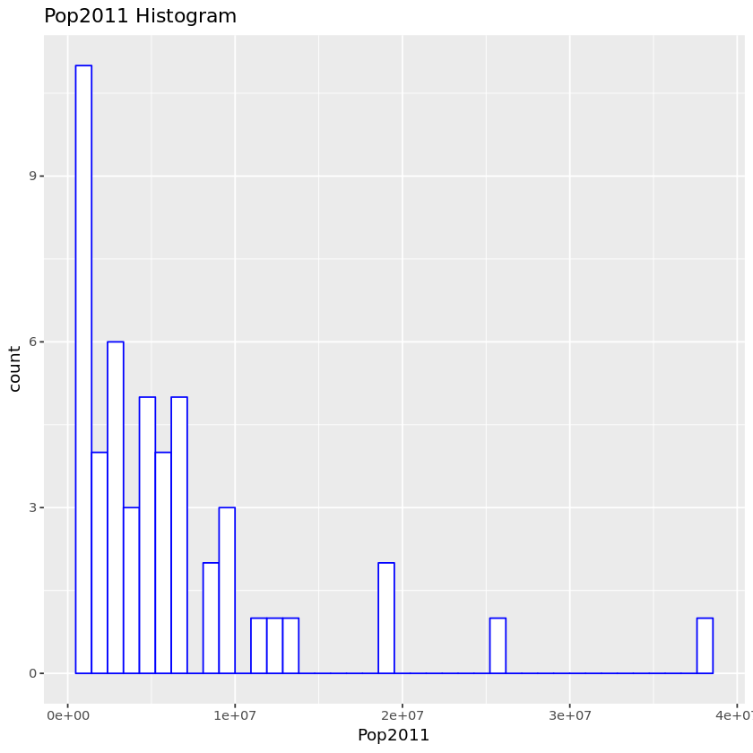

```r
ggplot(mergeDF) + # Specifying the dataframe in ggplot as mergeDF
aes(x=Pop2011) + # aesthetics where Pop2011 is specified to be kept on X Axis
geom_histogram(bins=40,color="blue",fill="white") + # Geometry to specify type of plot, histogram is used, with bins
#specifying number of bins/bars to be included in histogram, color for filing and boundaries is specified by fill & color respectively
ggtitle("Pop2011 Histogram") # ggtitle to specify name of the histogram plotted above
```

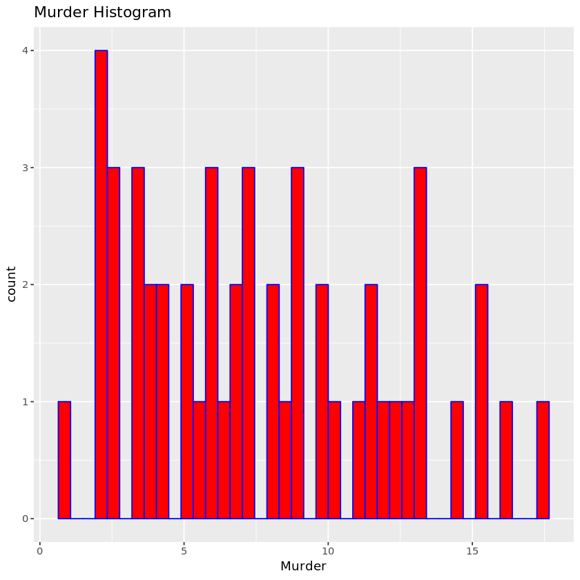

```r
ggplot(mergeDF) + # Specifying the dataframe in ggplot as mergeDF
aes(x=Murder) + # aesthetics where Murder is specified to be kept on X Axis
geom_histogram(bins=40,color="blue",fill="red") + # Geometry to specify type of plot, histogram is used, with bins
#specifying number of bins/bars to be included in histogram, color for filing and boundaries is specified by fill & color respectively
ggtitle("Murder Histogram") # ggtitle to specify name of the histogram plotted
```

Muder rate Histogram

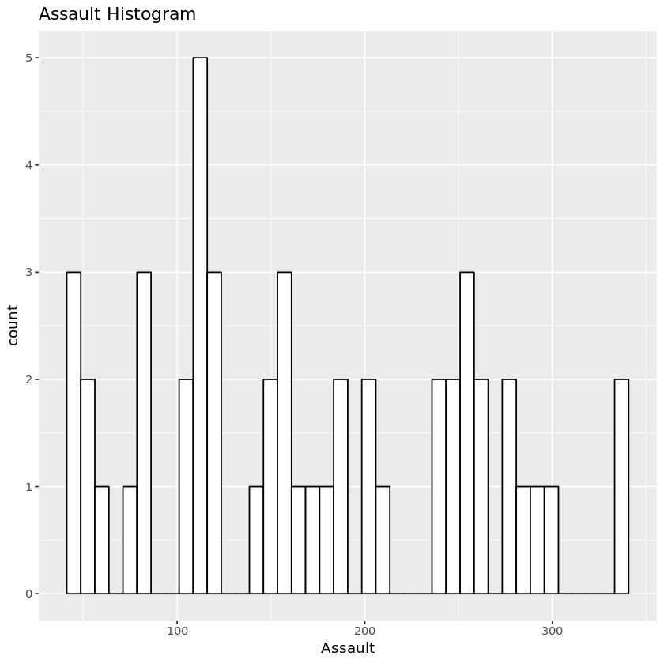

```r
ggplot(mergeDF) + # Specifying the dataframe in ggplot as mergeDF
aes(x=Assault) + # aesthetics where Assault is specified to be kept on X Axis
geom_histogram(bins=40,color="black",fill="white") + # Geometry to specify type of plot, histogram is used, with bins
#specifying number of bins/bars to be included in histogram, color for filing and boundaries is specified by fill & color respectively
ggtitle("Assault Histogram") # ggtitle to specify name of the histogram plotted
```

Assault Histogram

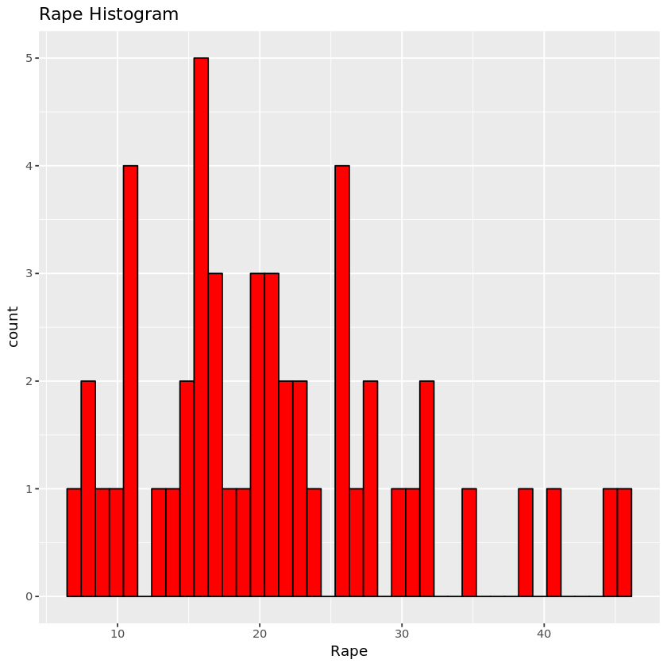

```r
ggplot(mergeDF) + # Specifying the dataframe in ggplot as mergeDF
  aes(x=Rape) + # aesthetics where Rape is specified to be kept on X Axis
  geom_histogram(bins=40,color="black",fill="red") + # Geometry to specify type of plot, histogram is used, with bins
#specifying number of bins/bars to be included in histogram, color for filing and boundaries is specified by fill & color respectively
  ggtitle("Rape Histogram") # ggtitle to specify name of the histogram plotted
```

Rape Histogram

Parameter to adjust to make the other histograms look right - Number of bins can be manipulated to make the histogram look right. The number of bins/bars have to be correct & different for each individual histogram so it can be visually correct to interpret.

C. Create a boxplot for the Pop2011, and a different boxplot for the murder rate.

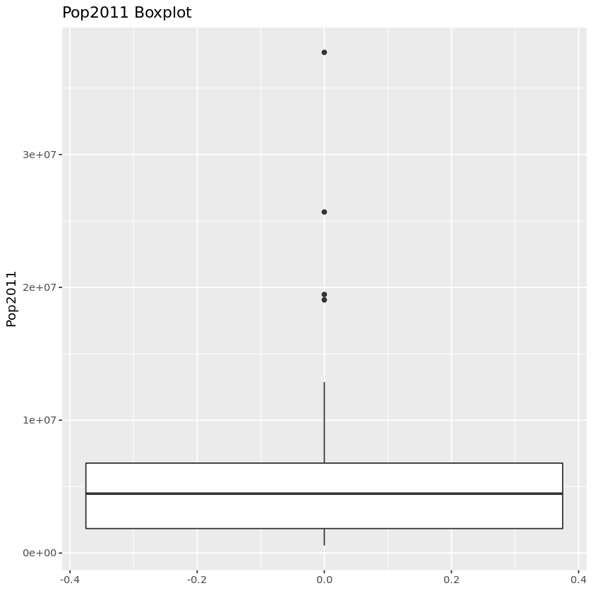

```r
ggplot(mergeDF) + # Specifying the dataframe in ggplot as mergeDF
  aes(y=Pop2011) + # aesthetics where Pop2011 is specified to be kept on Y Axis
  geom_boxplot() + # Geometry to specify type of plot here boxplot is used
  ggtitle("Pop2011 Boxplot") # ggtitle to specify name of the boxplot plotted
```

Pop2011 Boxplot

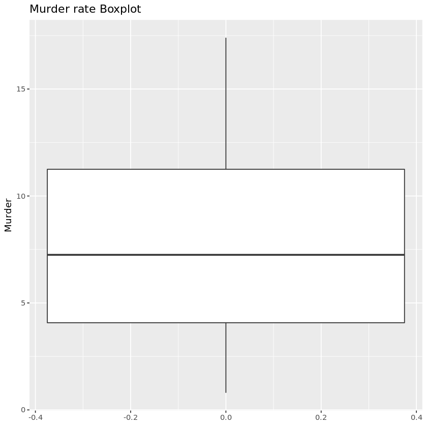

```r
ggplot(mergeDF) + # Specifying the dataframe in ggplot as mergeDF
  aes(y=Murder) + # aesthetics where Muder rate is specified to be kept on Y Axis
  geom_boxplot() + # Geometry to specify type of plot here boxplot is used
  ggtitle("Murder rate Boxplot") # ggtitle to specify name of the boxplot plotted
```

Murder Rate Boxplot

According to me, Boxplot was more helpful because it gives more details about the data including median, Q1(Quartile 1), Q3(Quartile 3), Outliers, Range, Inter Quartile Range(IQR) by just looking at the boxplot.

Step 2: Which State had the Most Murders – bar charts

A. Calculate the number of murders per state

```r
Murders_per_state <- (mergeDF$Murder * mergeDF$Pop2011)/100000 # Calculating the Murders per state from the Population and Murder rate
```

```r
Murders_per_state # Viewing Murders_per_state calculated above
```

1. 633.96168

2. 72.2718

3. 525.082905

4. 258.542152

5. 3392.27208

6. 404.226884

7. 118.163397

8. 53.520965

9. 2934.861468

10. 1707.84654

11. 72.86493

12. 41.20961

13. 1338.402728

14. 469.218384

15. 67.370798

16. 172.27428

17. 423.827532

18. 704.524744

19. 27.891948

20. 658.596657

21. 289.851584

22. 1195.018627

23. 144.311247

24. 479.540432

25. 540.96192

26. 59.89194

27. 79.233563

28. 332.245284

29. 27.682074

30. 652.76547

31. 237.373536

32. 2160.636867

33. 1255.33213

34. 5.471456

35. 842.781423

36. 250.239528

37. 189.721091

38. 802.801818

39. 35.744268

40. 673.80912

41. 31.315116

42. 845.242596

43. 3260.684487

44. 90.151104

45. 13.781482

46. 688.21134

47. 273.20152

48. 105.755748

49. 148.505942

50. 38.634744

```r
mergeDF$Murders_per_state <- ceiling(Murders_per_state) # Ceiling the Murders per state to the nearest value
#and copying it to new column in mergeDF dataframe Murders_per_state
```

```r
mergeDF # Viewing the final mergeDF dataframe with Murders_per_state included
```

A data.frame: 50 × 10

| stateName <chr> | Census <dbl> | Estimated <dbl> | Pop2010 <dbl> | Pop2011 <dbl> | Murder <dbl> | Assault <int> | UrbanPop <int> | Rape <dbl> | Murders_per_state <dbl> |
| --- | --- | --- | --- | --- | --- | --- | --- | --- | --- |
| Alabama | 4779736 | 4779735 | 4785401 | 4802740 | 13.2 | 236 | 58 | 21.2 | 634 |
| Alaska | 710231 | 710231 | 714146 | 722718 | 10.0 | 263 | 48 | 44.5 | 73 |
| Arizona | 6392017 | 6392013 | 6413158 | 6482505 | 8.1 | 294 | 80 | 31.0 | 526 |
| Arkansas | 2915918 | 2915921 | 2921588 | 2937979 | 8.8 | 190 | 50 | 19.5 | 259 |
| California | 37253956 | 37253956 | 37338198 | 37691912 | 9.0 | 276 | 91 | 40.6 | 3393 |
| Colorado | 5029196 | 5029196 | 5047692 | 5116796 | 7.9 | 204 | 78 | 38.7 | 405 |
| Connecticut | 3574097 | 3574097 | 3575498 | 3580709 | 3.3 | 110 | 77 | 11.1 | 119 |
| Delaware | 897934 | 897934 | 899792 | 907135 | 5.9 | 238 | 72 | 15.8 | 54 |
| Florida | 18801310 | 18801311 | 18838613 | 19057542 | 15.4 | 335 | 80 | 31.9 | 2935 |
| Georgia | 9687653 | 9687660 | 9712157 | 9815210 | 17.4 | 211 | 60 | 25.8 | 1708 |
| Hawaii | 1360301 | 1360301 | 1363359 | 1374810 | 5.3 | 46 | 83 | 20.2 | 73 |
| Idaho | 1567582 | 1567582 | 1571102 | 1584985 | 2.6 | 120 | 54 | 14.2 | 42 |
| Illinois | 12830632 | 12830632 | 12841980 | 12869257 | 10.4 | 249 | 83 | 24.0 | 1339 |
| Indiana | 6483802 | 6483800 | 6490622 | 6516922 | 7.2 | 113 | 65 | 21.0 | 470 |
| Iowa | 3046355 | 3046350 | 3050202 | 3062309 | 2.2 | 56 | 57 | 11.3 | 68 |
| Kansas | 2853118 | 2853118 | 2859143 | 2871238 | 6.0 | 115 | 66 | 18.0 | 173 |
| Kentucky | 4339367 | 4339362 | 4347223 | 4369356 | 9.7 | 109 | 52 | 16.3 | 424 |
| Louisiana | 4533372 | 4533372 | 4545343 | 4574836 | 15.4 | 249 | 66 | 22.2 | 705 |
| Maine | 1328361 | 1328361 | 1327379 | 1328188 | 2.1 | 83 | 51 | 7.8 | 28 |
| Maryland | 5773552 | 5773552 | 5785681 | 5828289 | 11.3 | 300 | 67 | 27.8 | 659 |
| Massachusetts | 6547629 | 6547629 | 6555466 | 6587536 | 4.4 | 149 | 85 | 16.3 | 290 |
| Michigan | 9883640 | 9883635 | 9877143 | 9876187 | 12.1 | 255 | 74 | 35.1 | 1196 |
| Minnesota | 5303925 | 5303925 | 5310658 | 5344861 | 2.7 | 72 | 66 | 14.9 | 145 |
| Mississippi | 2967297 | 2967297 | 2970072 | 2978512 | 16.1 | 259 | 44 | 17.1 | 480 |
| Missouri | 5988927 | 5988927 | 5995715 | 6010688 | 9.0 | 178 | 70 | 28.2 | 541 |
| Montana | 989415 | 989415 | 990958 | 998199 | 6.0 | 109 | 53 | 16.4 | 60 |
| Nebraska | 1826341 | 1826341 | 1830141 | 1842641 | 4.3 | 102 | 62 | 16.5 | 80 |
| Nevada | 2700551 | 2700551 | 2704283 | 2723322 | 12.2 | 252 | 81 | 46.0 | 333 |
| New Hampshire | 1316470 | 1316472 | 1316807 | 1318194 | 2.1 | 57 | 56 | 9.5 | 28 |
| New Jersey | 8791894 | 8791894 | 8799593 | 8821155 | 7.4 | 159 | 89 | 18.8 | 653 |
| New Mexico | 2059179 | 2059180 | 2065913 | 2082224 | 11.4 | 285 | 70 | 32.1 | 238 |
| New York | 19378102 | 19378104 | 19395206 | 19465197 | 11.1 | 254 | 86 | 26.1 | 2161 |
| North Carolina | 9535483 | 9535475 | 9560234 | 9656401 | 13.0 | 337 | 45 | 16.1 | 1256 |
| North Dakota | 672591 | 672591 | 674629 | 683932 | 0.8 | 45 | 44 | 7.3 | 6 |
| Ohio | 11536504 | 11536502 | 11537968 | 11544951 | 7.3 | 120 | 75 | 21.4 | 843 |
| Oklahoma | 3751351 | 3751354 | 3760184 | 3791508 | 6.6 | 151 | 68 | 20.0 | 251 |
| Oregon | 3831074 | 3831074 | 3838332 | 3871859 | 4.9 | 159 | 67 | 29.3 | 190 |
| Pennsylvania | 12702379 | 12702379 | 12717722 | 12742886 | 6.3 | 106 | 72 | 14.9 | 803 |
| Rhode Island | 1052567 | 1052567 | 1052528 | 1051302 | 3.4 | 174 | 87 | 8.3 | 36 |
| South Carolina | 4625364 | 4625364 | 4637106 | 4679230 | 14.4 | 279 | 48 | 22.5 | 674 |
| South Dakota | 814180 | 814180 | 816598 | 824082 | 3.8 | 86 | 45 | 12.8 | 32 |
| Tennessee | 6346105 | 6346110 | 6357436 | 6403353 | 13.2 | 188 | 59 | 26.9 | 846 |
| Texas | 25145561 | 25145561 | 25253466 | 25674681 | 12.7 | 201 | 80 | 25.5 | 3261 |
| Utah | 2763885 | 2763885 | 2775479 | 2817222 | 3.2 | 120 | 80 | 22.9 | 91 |
| Vermont | 625741 | 625741 | 625909 | 626431 | 2.2 | 48 | 32 | 11.2 | 14 |
| Virginia | 8001024 | 8001030 | 8023953 | 8096604 | 8.5 | 156 | 63 | 20.7 | 689 |
| Washington | 6724540 | 6724540 | 6742950 | 6830038 | 4.0 | 145 | 73 | 26.2 | 274 |
| West Virginia | 1852994 | 1852996 | 1854368 | 1855364 | 5.7 | 81 | 39 | 9.3 | 106 |
| Wisconsin | 5686986 | 5686986 | 5691659 | 5711767 | 2.6 | 53 | 66 | 10.8 | 149 |
| Wyoming | 563626 | 563626 | 564554 | 568158 | 6.8 | 161 | 60 | 15.6 | 39 |

B. Generate a bar chart, with the number of murders per state

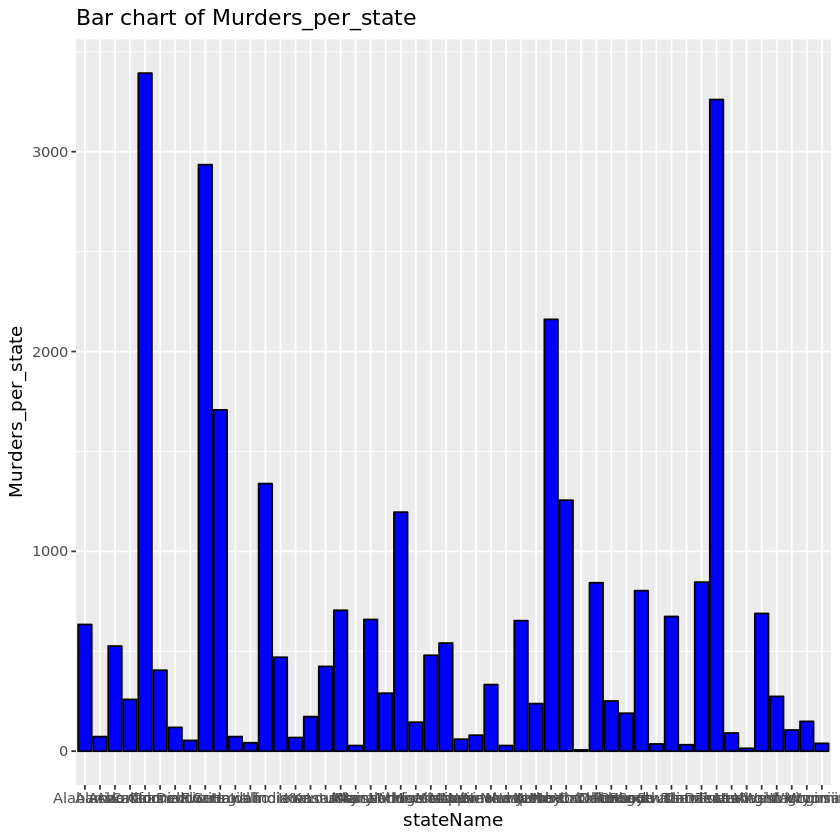

```r
ggplot(mergeDF) + # Specifying the dataframe in ggplot as mergeDF
aes(y=Murders_per_state,x=stateName) + # aesthetics where Muder_per_state is specified on Y Axis, stateName on X Axis
geom_col(color="black",fill="blue") + # Geometry to specify type of plot here barchart is used
#with blue filled bars/bins separated by black boundaries using color & fill respectively.
ggtitle("Bar chart of Murders_per_state") # ggtitle to specify name of the barchart plotted
```

Bar Chart Murders per state

C. Generate a bar chart, with the number of murders per state. Rotate text (on the X axis), so we can see x labels, also add a title named “Total Murders”.

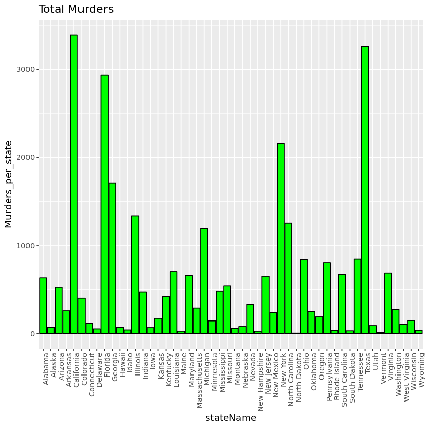

```r
ggplot(mergeDF) + # Specifying the dataframe in ggplot as mergeDF
aes(y=Murders_per_state,x=stateName) + # aesthetics where Muder_per_state is specified on Y Axis, stateName on X Axis
geom_col(color="black",fill="green") + theme(axis.text.x = element_text(angle = 90, hjust = 1)) + #Geometry to specify type of
#plot here barchart is used, green bins seaprated by black boundaries, theme to rotate X Axis labels by 90 degrees.
ggtitle("Total Murders") # ggtitle to specify name of the barchart plotted
```

Theme used

D.Generate a new bar chart, the same as in the previous step, but also sort the x-axis by the murder rate from low to high

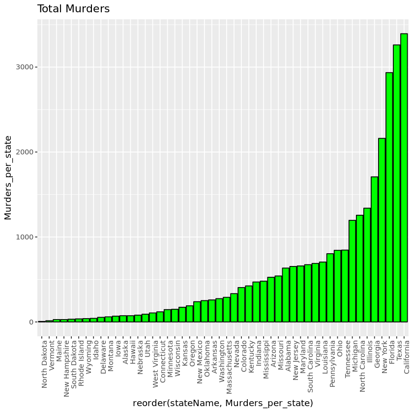

```r
ggplot(mergeDF) + # Specifying the dataframe in ggplot as mergeDF
aes(y = Murders_per_state, x = reorder(stateName,Murders_per_state)) + # aesthetics where Muder_per_state is specified on Y Axis,
# stateName on X Axis, ordering stateNames based on murders_per_state from lowest to highest
geom_col(color="black",fill="green") + theme(axis.text.x = element_text(angle = 90, hjust = 1)) + #Geometry to specify type of
#plot here barchart is used, green bins seaprated by black boundaries, theme to rotate X Axis labels by 90 degrees.
ggtitle("Total Murders") # ggtitle to specify name of the barchart plotted
```

Reordered X-Axis based on Murder_per_state from low to high

E. Generate a third bar chart, the same as the previous step, but also showing UrbanPop as the color of the bar

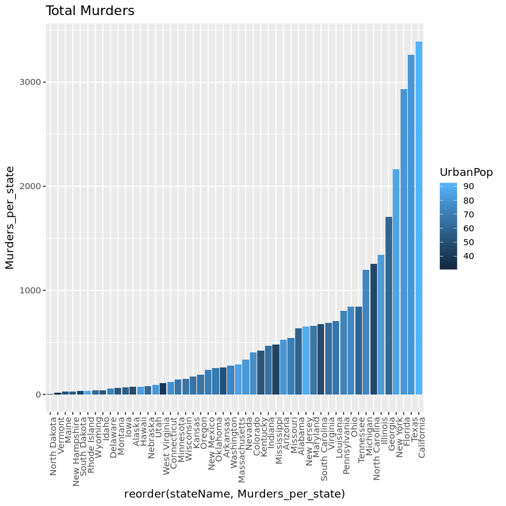

```r
ggplot(mergeDF) + # Specifying the dataframe in ggplot as mergeDF
aes(y = Murders_per_state, fill=UrbanPop, x = reorder(stateName,Murders_per_state)) + # aesthetics where Muder_per_state is specified on Y Axis,
# stateName on X Axis, ordering stateNames based on murders_per_state from lowest to highest , fill bins using UrbanPop Column
geom_col() + theme(axis.text.x = element_text(angle = 90, hjust = 1)) + # Specifying barchart for the type of plot &
# theme to rotate X Axis labels by 90 degrees.
ggtitle("Total Murders") # ggtitle to specify name of the barchart plotted
```

showing UrbanPop as the color of the bar for the previous one

```r
Step 3: Explore Murders – scatter chart
```

Generate a scatter plot – have Pop2011 on the X axis, the UrbanPop on the y axis, and the size & color represent the number of murders.

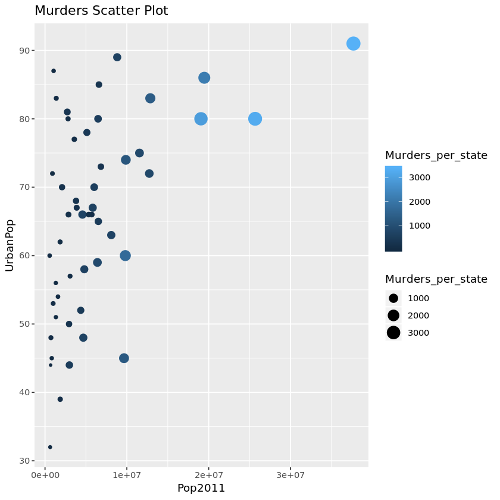

```r
ggplot(mergeDF) + # Specifying the dataframe in ggplot as mergeDF
aes(y = UrbanPop, x = Pop2011) + #aesthetics where UrbanPop is specified on Y Axis, Pop2011 on X Axis
geom_point(aes(size=Murders_per_state,color=Murders_per_state)) + # Specifying Scatter plot to be used as type of plot &
# murders_per_state as the size of points and color.
ggtitle("Murders Scatter Plot") # ggtitle to specify name of the scatter plot plotted
```

Scatter Plot for the murders